# [Chapter 8] Cleaning the Ames housing data

[DSLC stages]: Data cleaning and pre-processing

Let’s start by loading in the libraries that we will use in this document.

```r
# load the libraries we will need in this document
library(tidyverse)
library(lubridate)
library(janitor)
library(fastDummies)
```

## 1 Domain problem formulation

Our overall goal for this project is to develop a predictive algorithm that we can use to predict the sale price of houses in Ames, Iowa.

## 2 Data source overview

The data we will use was collated in 2011 by Dean De Cock [@de_cock_ames_2011]. The original paper discussing this data can be found [here](http://jse.amstat.org/v19n3/decock.pdf) as well as in the file `data/data_documentation/decock_ames_2011.pdf`.

De Cock obtained this data directly from the Ames City Assessor’s Office following a brief meeting with the Assessor and Deputy Assessor.

## 3 Step 1: Review background information

### 3.1 Information on data collection

We don’t know a whole lot about how the numbers in the data were collected, i.e. were all houses assessed by the same assessor(s)? Did the assessor collecting the information use a paper form, and then put the information into a spreadsheet or did the assessor collecting the information record it directly on a computer?

We do know that the data De Cock received contained several variables that were very specific to the Assessor’s office uses, such as weighting and adjustment factors used in the city’s modeling system, and that De Cock removed these variables.

Note that an Assessor’s office is *not* a real-estate office or sales office. The purpose of the assessor’s office is “discovering changes in real property, such as new construction, and maintaining the classification and values for the entire tax base of Ames”. To be eligible to be appointed an assessor in Iowa for a six-year term, one needs to pass a comprehensive examination. In order to be reappointed, “150 hours of state-approved continuing education, of which at least 90 hours must be tested courses, are required during the six-year term”.

This information (and more) was found directly on the [City of Ames](https://www.cityofames.org/government/departments-divisions-a-h/city-assessor/reports) website. We saved the “Ames City Assessor’s Budget Proposal for the 2022-2023 Fiscal Year” pdf document in the file `data/data_documentation/additional_assessor_information.pdf`. This document, while not of the same time period as the data we will be examining, gives a reasonable sense of what kind of duties the City Assessor’s office performs and what kind of data they collect.

### 3.2 Data dictionary

The data dictionary is provided in file `data/additional_info/DataDocumentation.txt`.

The response variable for this project is the sale price (`SalePrice`) of each house. The `ORDER` and `PID` columns seem to correspond to row and house identifier columns.

One thing that we notice is that there are a lot of related variables.

One question that arises is whether the `Bsmt Unf Sf`, `BsmtFin SF 1`, and `BsmtFin SF 2`, all add up to `Total Bsmt SF`? If so, this may cause issues of colinearity when we try to fit our predictive algorithms unless we remove one of the variables (or remove all three of the sub-variables and just keep `Total Bsmt SF`).

**Question: do the `Bsmt Unf Sf`, `BsmtFin SF 1`, and `BsmtFin SF 2`, all add up to `Total Bsmt SF`**

Check whether the three basement square footage variables add up to the total basement square footage variable. If so, likely we will want to remove one of the `Bsmt Unf Sf`, `BsmtFin SF 1`, and `BsmtFin SF 2` variables, or remove all three if we want to actively simplify the data.

Similarly, we are curious whether general square footage variables (`1st Flr SF`, `2nd Flr SF`, `Total Bsmt SF` and `Low Qual Fin SF`) add up to the `gr_liv_area` variable.

**Question: do any combination of the `1st Flr SF`, `2nd Flr SF`, `Total Bsmt SF` and `Low Qual Fin SF` add up to `Gr Liv Area`?**

Check whether any combination of the general square footage variables add up to the greater living area variables. Again, if so, likely we will want to remove one of the `...SF` variables, or remove all three if we want to actively simplify the data.

### 3.3 Answering questions about the background information

In this section, we will go through the recommended background information questions from the Data Cleaning chapter.

- *What does each variable measure?* Most of the information in the data dictionary is fairly self-explanatory.
- *How was the data collected?* We don’t know for sure, but if we are to picture the data collection process we *assume* that an appointed assessor visited each house and recorded the information on a form, and then later input this information into a database or spreadsheet. This is purely speculation, however, since we don’t have enough information to be able to properly picture how the data was collected.
- *What are the observational units?* The observational units are the houses.
- *Is the data relevant to my project?* Actually, since we are interested in generating an algorithm to predict the sale price of houses for sale in our current time period, and this dataset spans the years 2006-2010, this data is actually likely *not* relevant to our project. We will explore this more below in Section 3.4.

### 3.4 Exploring data relevance using zillow data

To explore whether the housing prices from 2006-2010 that is being reflected by this data bear any resemblance to housing prices more than a decade later, we turn to Zillow, which provides a large amount of [public real estate data](https://www.zillow.com/research/data/) (although not at the level of detail on each house that we got from De Cock’s Ames Assessor data).

First let’s load in the data that we downloaded from Zillow’s website (we saved the file as `ames_zillow.csv`):

```r
zillow_prices <- read_csv("../data/ames_zillow.csv")
```

Next, we will filter to the relevant information:

```r
zillow_prices_ames <- zillow_prices |>
  filter(RegionName == "Ames", StateName == "IA") |>
  select(-RegionID, -SizeRank, -RegionName, -RegionType, -StateName, -State, -Metro, -CountyName) |>
  pivot_longer(cols = everything(),
               names_to = "date", values_to = "price") |>
  mutate(date = ymd(date)) |>
  filter(date >= ymd("2005-03-31"))
```

Then we will create a line plot that shows the house price trends over time, with the time period covered by De Cock’s Assessor’s office data highlighted in grey.

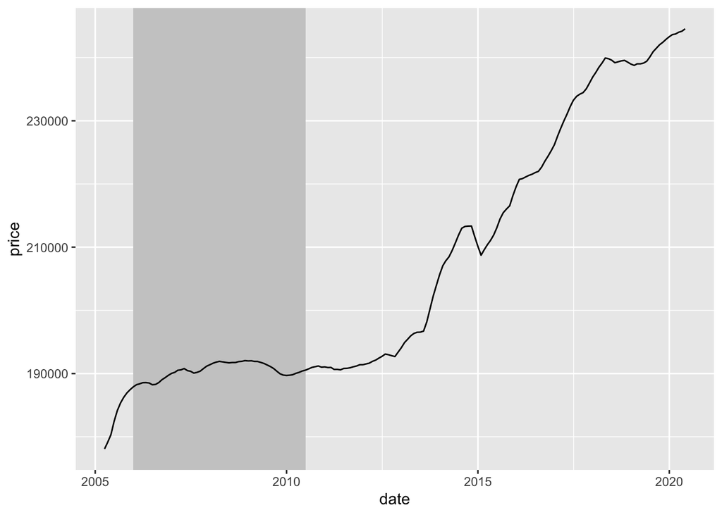

```r
zillow_prices_ames |>
  ggplot() +
  # add a grey rectangle over the De Cock data study period
  geom_rect(aes(xmin = ymd("2006-01-01"), xmax = ymd("2010-07-01"),
                ymin = -Inf, ymax = Inf),
            fill = "grey80", alpha = 0.3) +
  geom_line(aes(x = date, y = price))
```

It is disturbingly clear that the sale prices during the time period that De Cock’s data covers are *very* different to the sale prices a decade later. There is a general trend where house prices in Ames have grown immensely over the past decade, from an average of around $190,000 in 2010, to an average of around $240,000 in 2020. Any predictive algorithm that we build using data from 2006 to mid-2010 is going to vastly under-predict the sale price for houses today.

Our problem now is that there doesn’t exist a publicly available Ames housing dataset (that includes information on the features of the individual houses) for a broader data range. De Cock originally collected this data by getting in touch directly with the Ames City Assessor’s Office, and asking for permission to make the data public. Since we did not want to bother the Assessor’s Office for this educational example, and we won’t be applying whatever algorithm we create in real life, we will still use this dataset for demonstration purposes, but we will make a compromise: we’re going to use our imagination and *pretend that we live in the year 2011* (the year after De Cock’s dataset ends).

## 4 Step 2: Loading the data

Fortunately the data consists of only one single file. But this file is a `.txt` file, rather than a `.csv` file, so we can’t use our trusty `read_csv()` function.

Instead, we will use the generic base R (i.e., non-tidyverse) `read.table()` function. This function requires us to specify how entries are separated from one another in the data. A quick look and experimentation implies that it is tab-separated (every entry in the data is separated by a tab).

```r
ames_orig <- read.table("../data/AmesHousing.txt",
                               sep = "\t", header = T)
```

Let’s look at the first few rows to make sure it looks like it has been loaded in correctly:

```r
head(ames_orig)
```

| Order | PID | MS.SubClass | MS.Zoning | Lot.Frontage | Lot.Area | Street | Alley | Lot.Shape | Land.Contour | Utilities | Lot.Config | Land.Slope | Neighborhood | Condition.1 | Condition.2 | Bldg.Type | House.Style | Overall.Qual | Overall.Cond | Year.Built | Year.Remod.Add | Roof.Style | Roof.Matl | Exterior.1st | Exterior.2nd | Mas.Vnr.Type | Mas.Vnr.Area | Exter.Qual | Exter.Cond | … |
| --- | --- | --- | --- | --- | --- | --- | --- | --- | --- | --- | --- | --- | --- | --- | --- | --- | --- | --- | --- | --- | --- | --- | --- | --- | --- | --- | --- | --- | --- | --- |
| 1 | 526301100 | 20 | RL | 141 | 31770 | Pave | NA | IR1 | Lvl | AllPub | Corner | Gtl | NAmes | Norm | Norm | 1Fam | 1Story | 6 | 5 | 1960 | 1960 | Hip | CompShg | BrkFace | Plywood | Stone | 112 | TA | TA | … |
| 2 | 526350040 | 20 | RH | 80 | 11622 | Pave | NA | Reg | Lvl | AllPub | Inside | Gtl | NAmes | Feedr | Norm | 1Fam | 1Story | 5 | 6 | 1961 | 1961 | Gable | CompShg | VinylSd | VinylSd | None | 0 | TA | TA | … |
| 3 | 526351010 | 20 | RL | 81 | 14267 | Pave | NA | IR1 | Lvl | AllPub | Corner | Gtl | NAmes | Norm | Norm | 1Fam | 1Story | 6 | 6 | 1958 | 1958 | Hip | CompShg | Wd Sdng | Wd Sdng | BrkFace | 108 | TA | TA | … |
| 4 | 526353030 | 20 | RL | 93 | 11160 | Pave | NA | Reg | Lvl | AllPub | Corner | Gtl | NAmes | Norm | Norm | 1Fam | 1Story | 7 | 5 | 1968 | 1968 | Hip | CompShg | BrkFace | BrkFace | None | 0 | Gd | TA | … |
| 5 | 527105010 | 60 | RL | 74 | 13830 | Pave | NA | IR1 | Lvl | AllPub | Inside | Gtl | Gilbert | Norm | Norm | 1Fam | 2Story | 5 | 5 | 1997 | 1998 | Gable | CompShg | VinylSd | VinylSd | None | 0 | TA | TA | … |
| 6 | 527105030 | 60 | RL | 78 | 9978 | Pave | NA | IR1 | Lvl | AllPub | Inside | Gtl | Gilbert | Norm | Norm | 1Fam | 2Story | 6 | 6 | 1998 | 1998 | Gable | CompShg | VinylSd | VinylSd | BrkFace | 20 | TA | TA | … |

And let’s examine the dimension of the data.

```r
dim(ames_orig)
```

```
[1] 2930   82
```

Everything seems to match what we expected from the data dictionary above (except the column names got a bit warped in the loading - they now have periods instead of spaces and variables that started with a number now have a preceding “X”).

### 4.1 Filtering to the relevant portion of the data

Since we are only interested in *houses* sold in so-called “normal” sales (i.e., we don’t want to include foreclosures, within-family sales, sales of incomplete homes, etc), we will filter the data to just include such sales. We will also exclude agricultural, commercial, and industrial sales.

Note that now we are editing the data, we create a new object `ames` so that we still have a copy of the originally loaded dataset in our environment (`ames_orig`).

```r
ames <- ames_orig |>
  filter(Sale.Condition == "Normal",
         # remove agricultural, commercial and industrial
         !(MS.Zoning %in% c("A (agr)", "C (all)", "I (all)")))
```

While we could apply whatever data cleaning function we write below to this pre-filtered version of the data, it will be helpful to instead write a function that, if applied to the original (unfiltered) version of the data will do this filtering step too. Thus we will note down a data loading action item to include in our cleaning/pre-processing function.

**Data loading action item: filter to “normal” sales and zones only**

Ensure that the data only contains `Sale Condition == "Normal"` and `MS.Zoning` is not equal to any of `"A (agr)", "C (all)", "I (all)"`

## 5 Step 3: Examine the data

In this section we explore the common messy data traits to identify any cleaning action items.

### 5.1 Finding invalid values

Following the suggested explorations for identifying invalid values, we will first look at randomly selected rows of the data to get a sense for what the values in each column look like.

```r
ames |>
  sample_n(10)
```

| Order | PID | MS.SubClass | MS.Zoning | Lot.Frontage | Lot.Area | Street | Alley | Lot.Shape | Land.Contour | Utilities | Lot.Config | Land.Slope | Neighborhood | Condition.1 | Condition.2 | Bldg.Type | House.Style | Overall.Qual | Overall.Cond | Year.Built | Year.Remod.Add | Roof.Style | Roof.Matl | Exterior.1st | Exterior.2nd | Mas.Vnr.Type | Mas.Vnr.Area | Exter.Qual | Exter.Cond | … |
| --- | --- | --- | --- | --- | --- | --- | --- | --- | --- | --- | --- | --- | --- | --- | --- | --- | --- | --- | --- | --- | --- | --- | --- | --- | --- | --- | --- | --- | --- | --- |
| 492 | 528292040 | 60 | RL | NA | 24682 | Pave | NA | IR3 | Lvl | AllPub | CulDSac | Gtl | Gilbert | RRAn | Norm | 1Fam | 2Story | 6 | 5 | 1999 | 1999 | Gable | CompShg | VinylSd | VinylSd | None | 0 | TA | TA | … |
| 2249 | 914452120 | 85 | RL | NA | 7540 | Pave | NA | IR1 | Lvl | AllPub | CulDSac | Gtl | Mitchel | Norm | Norm | 1Fam | SFoyer | 6 | 6 | 1978 | 1978 | Gable | CompShg | VinylSd | VinylSd | None | 0 | TA | TA | … |
| 859 | 907227030 | 20 | RL | 36 | 15523 | Pave | NA | IR1 | Lvl | AllPub | CulDSac | Gtl | CollgCr | Norm | Norm | 1Fam | 1Story | 5 | 6 | 1972 | 1972 | Gable | CompShg | HdBoard | Plywood | None | 0 | TA | TA | … |
| 482 | 528250040 | 60 | RL | NA | 8174 | Pave | NA | IR1 | Lvl | AllPub | Inside | Gtl | Gilbert | Norm | Norm | 1Fam | 2Story | 7 | 5 | 2003 | 2003 | Gable | CompShg | VinylSd | VinylSd | None | 0 | Gd | TA | … |
| 642 | 535302120 | 90 | RL | 76 | 9482 | Pave | NA | Reg | Lvl | AllPub | Inside | Gtl | NAmes | Norm | Norm | Duplex | 1Story | 5 | 4 | 1958 | 1958 | Hip | CompShg | Wd Sdng | Wd Sdng | BrkFace | 657 | TA | TA | … |
| 1196 | 534225110 | 90 | RL | 72 | 11072 | Pave | NA | IR1 | Lvl | AllPub | Inside | Gtl | NAmes | Norm | Norm | Duplex | 1Story | 5 | 5 | 1965 | 1965 | Gable | CompShg | HdBoard | HdBoard | None | 0 | TA | TA | … |
| 1704 | 528120150 | 60 | RL | 76 | 9591 | Pave | NA | Reg | Lvl | AllPub | Inside | Gtl | NridgHt | Norm | Norm | 1Fam | 2Story | 8 | 5 | 2004 | 2005 | Gable | CompShg | VinylSd | VinylSd | BrkFace | 344 | Gd | TA | … |
| 2886 | 913350030 | 20 | RL | 69 | 23580 | Pave | NA | IR1 | Lvl | AllPub | Inside | Mod | Mitchel | Norm | Norm | 1Fam | 1Story | 6 | 6 | 1979 | 1979 | Gable | CompShg | Plywood | Plywood | None | 0 | TA | TA | … |
| 2617 | 535425050 | 20 | RL | 86 | 11650 | Pave | NA | Reg | Lvl | AllPub | Corner | Gtl | NAmes | PosA | Norm | 1Fam | 1Story | 7 | 5 | 1959 | 1959 | Hip | CompShg | Plywood | Plywood | BrkCmn | 58 | TA | TA | … |
| 756 | 903458170 | 30 | RM | 52 | 6240 | Pave | Grvl | Reg | Lvl | AllPub | Inside | Gtl | IDOTRR | Norm | Norm | 1Fam | 1.5Fin | 4 | 5 | 1925 | 1950 | Gable | CompShg | MetalSd | MetalSd | None | 0 | TA | TA | … |

#### 5.1.1 Numeric variables

To explore the validity of the values in the numeric variables, we will first look at the min, max, and mean for each column.

```r
ames |>
  select_if(is.numeric) |>
  map_df(~tibble(min = min(., na.rm = TRUE),
                 max = max(., na.rm = TRUE),
                 mean = round(mean(., na.rm = TRUE), 2)),
         .id = "variable") |>
  # a hack to make it print out all the rows
  as.data.frame()
```

| variable | min | max | mean |
| --- | --- | --- | --- |
| Order | 1 | 2930 | 1418.37 |
| PID | 526301100 | 924152030 | 716776374.12 |
| MS.SubClass | 20 | 190 | 57.93 |
| Lot.Frontage | 21 | 313 | 68.18 |
| Lot.Area | 1300 | 215245 | 10037.71 |
| Overall.Qual | 1 | 10 | 6.02 |
| Overall.Cond | 1 | 9 | 5.65 |
| Year.Built | 1872 | 2010 | 1969.79 |
| Year.Remod.Add | 1950 | 2010 | 1983.41 |
| Mas.Vnr.Area | 0 | 1600 | 96.73 |
| BsmtFin.SF.1 | 0 | 2288 | 441.09 |
| BsmtFin.SF.2 | 0 | 1526 | 55.49 |
| Bsmt.Unf.SF | 0 | 2336 | 529.14 |
| Total.Bsmt.SF | 0 | 3206 | 1025.72 |
| X1st.Flr.SF | 334 | 3820 | 1135.50 |
| X2nd.Flr.SF | 0 | 1872 | 339.22 |
| Low.Qual.Fin.SF | 0 | 1064 | 4.34 |
| Gr.Liv.Area | 334 | 4316 | 1479.06 |
| Bsmt.Full.Bath | 0 | 2 | 0.43 |
| Bsmt.Half.Bath | 0 | 2 | 0.06 |
| Full.Bath | 0 | 4 | 1.54 |
| Half.Bath | 0 | 2 | 0.38 |
| Bedroom.AbvGr | 0 | 6 | 2.86 |
| Kitchen.AbvGr | 0 | 3 | 1.04 |
| TotRms.AbvGrd | 2 | 13 | 6.37 |
| Fireplaces | 0 | 4 | 0.61 |
| Garage.Yr.Blt | 1900 | 2009 | 1976.46 |
| Garage.Cars | 0 | 5 | 1.74 |
| Garage.Area | 0 | 1488 | 462.49 |
| Wood.Deck.SF | 0 | 1424 | 96.40 |
| Open.Porch.SF | 0 | 570 | 44.82 |
| Enclosed.Porch | 0 | 1012 | 23.15 |
| X3Ssn.Porch | 0 | 508 | 2.48 |
| Screen.Porch | 0 | 576 | 16.36 |
| Pool.Area | 0 | 800 | 1.79 |
| Misc.Val | 0 | 15500 | 51.59 |
| Mo.Sold | 1 | 12 | 6.11 |
| Yr.Sold | 2006 | 2010 | 2007.87 |
| SalePrice | 35000 | 755000 | 176172.01 |

Since it can be hard to tell if the maximums and minimums are reasonable, it is often helpful to visualize the distribution of each numeric variable using a histogram:

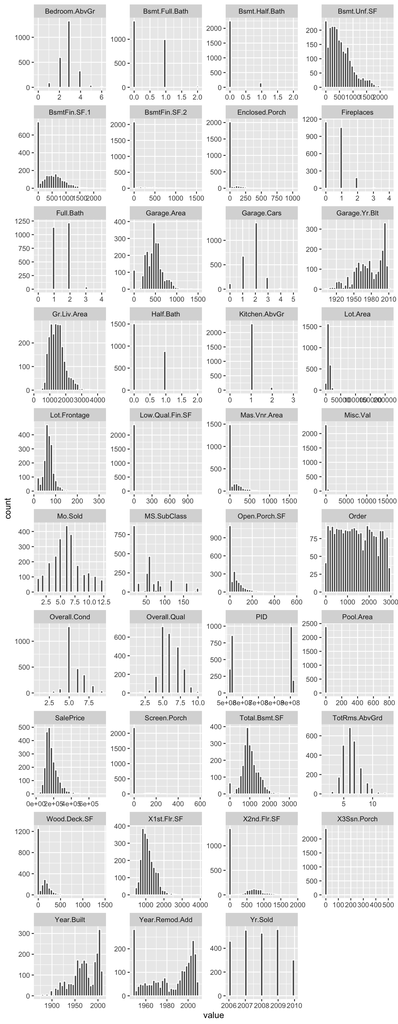

Figure 1: Histograms showing the distribution of each variable

```r
ames |>
  select_if(is.numeric) |>
  pivot_longer(everything(), names_to = "variable") |>
  ggplot() +
  geom_histogram(aes(x = value), col = "white") +
  facet_wrap(~variable, scales = "free", ncol = 4)
```

When the x-axis range of a histogram appears to be much wider than the data (e.g., every value seems to be 0, but the range goes up to 600), this sometimes means that there are some very large values that are atypical. We see this for quite a few of the variables, such as `Misc.Val`, `Low.Qual.Fin.SF`, `Screen.Porch`, etc.

While such atypically large entries are not necessarily in error, their presence should warrant further exploration. Let’s look at some of these variables by investigating ordering the values from largest to smallest:

A quick look at the 250 largest values for `Screen.Porch` shows us that, while there are only 200 or so non-zero values (out of more than 2,000), they don’t look particularly unusual (they might look unusual look off if all of them were `9999`, for example, or if one was aggressively larger than the rest).

```r
ames |>
  arrange(desc(Screen.Porch)) |>
  pull(Screen.Porch) |>
  head(250)
```

```
  [1] 576 490 480 440 410 396 385 374 348 342 322 291 288 288 288 288 287 280
 [19] 276 273 271 270 266 265 264 263 259 259 256 256 256 255 252 240 240 234
 [37] 228 227 227 225 225 225 224 224 224 224 222 221 220 217 216 216 216 216
 [55] 216 216 216 216 210 210 208 204 204 201 200 200 200 200 200 200 198 197
 [73] 196 195 195 195 192 192 192 192 192 192 192 192 192 190 189 189 189 185
 [91] 184 182 182 182 180 180 180 180 180 180 180 178 176 176 175 175 175 171
[109] 170 170 168 168 168 168 168 168 168 166 165 165 163 162 161 161 160 160
[127] 160 156 156 156 155 155 155 155 154 153 152 150 148 147 147 145 145 144
[145] 144 144 144 144 144 144 144 144 144 144 144 144 143 142 142 141 140 140
[163] 138 135 130 128 126 126 126 126 123 122 121 120 120 120 120 120 120 120
[181] 119 117 116 116 115 115 113 112 112 111 110 110 109 108 104 100 100 100
[199] 100 100  95  95  94  92  90  90  90  88  80  53  40   0   0   0   0   0
[217]   0   0   0   0   0   0   0   0   0   0   0   0   0   0   0   0   0   0
[235]   0   0   0   0   0   0   0   0   0   0   0   0   0   0   0   0
```

Similarly, a look at the largest values for `Low.Qual.Fin.SF` shows that there are only 30 or so non-zero values, rendering this variable fairly uninformative to begin with. The non-zero values themselves don’t necessarily look odd.

```r
ames |>
  arrange(desc(Low.Qual.Fin.SF)) |>
  pull(Low.Qual.Fin.SF) |>
  head(100)
```

```
  [1] 1064  697  572  528  514  512  481  479  473  420  397  390  384  362  360
 [16]  360  312  259  234  232  205  205  156  144  140  120  108   80   80   80
 [31]   53    0    0    0    0    0    0    0    0    0    0    0    0    0    0
 [46]    0    0    0    0    0    0    0    0    0    0    0    0    0    0    0
 [61]    0    0    0    0    0    0    0    0    0    0    0    0    0    0    0
 [76]    0    0    0    0    0    0    0    0    0    0    0    0    0    0    0
 [91]    0    0    0    0    0    0    0    0    0    0
```

We find similar things for the other variables too.

One variable that does look a little bit strange is `Year.Remod.Add`. Notice that there is a strange peak at 1950:

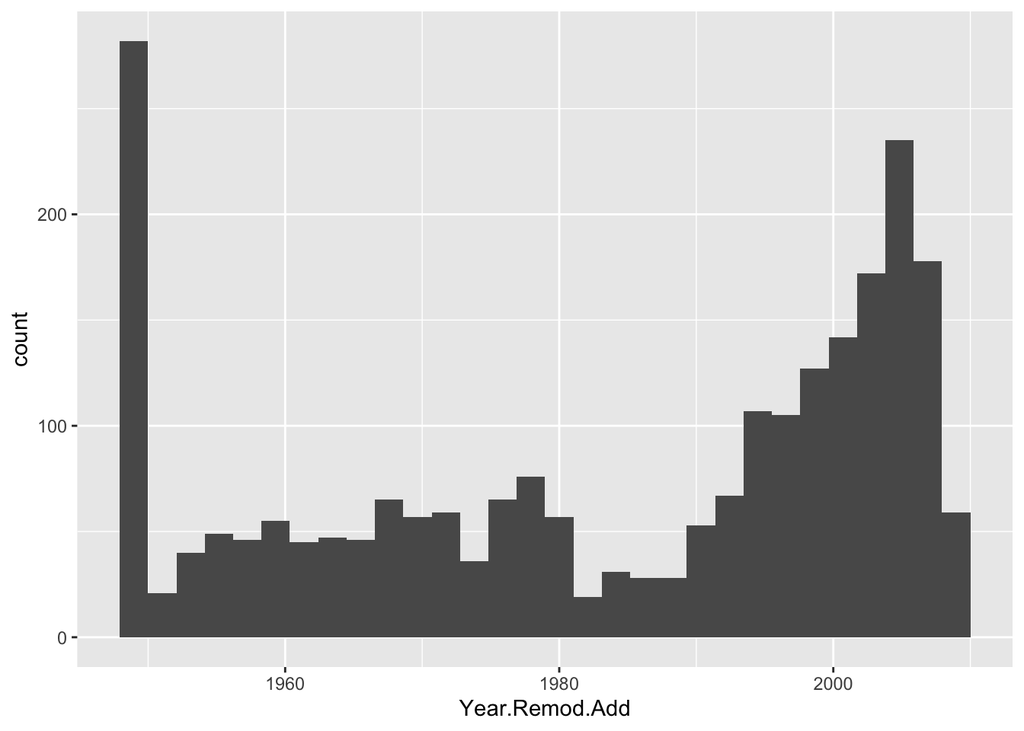

```r
ames |>
  ggplot() +
  geom_histogram(aes(x = Year.Remod.Add))
```

```r
ames |>
  count(Year.Remod.Add) |>
  head(10)
```

| Year.Remod.Add | n |
| --- | --- |
| 1950 | 282 |
| 1951 | 10 |
| 1952 | 11 |
| 1953 | 18 |
| 1954 | 22 |
| 1955 | 22 |
| 1956 | 27 |
| 1957 | 19 |
| 1958 | 27 |
| 1959 | 28 |

Since there are many houses built before 1950, our best guess is that a value of 1950 either means that no remodel was added, or it was added before 1950 before good records were kept.

Another thought that comes to mind is that it is unlikely that every house had a remodel. Let’s compare the `Year.Built` variable with the `Year.Remod.Add` variable in the scatterplot below:

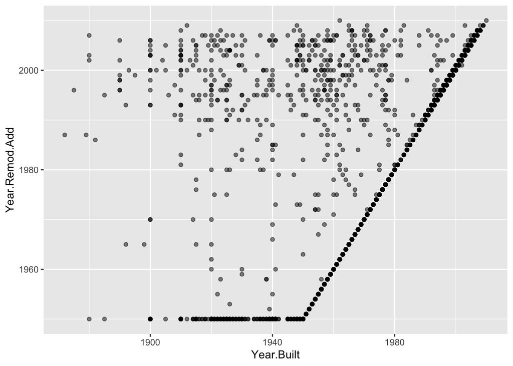

```r
ames |>
  ggplot() +
  geom_point(aes(x = Year.Built, y = Year.Remod.Add),
             alpha = 0.5)
```

From the figure, we fortunately see that there were no remodels added *before* the houses were built, and it seems fairly reasonable to assume that most of the remodels listed as 1950 are “fake”. It might make sense to replace the `Year.Remod.Add` values of 1950 with the corresponding house’s `Year.Built` value.

Let’s see how many of the non-1950s remodel houses has their `Year.Remod.Add` value equal to their `Year.Built` value:

```r
ames |>
  filter(Year.Remod.Add > 1950) |>
  count(Year.Remod.Add == Year.Built)
```

| Year.Remod.Add == Year.Built | n |
| --- | --- |
| FALSE | 832 |
| TRUE | 1283 |

**Data cleaning action item: Replace `Year.Remod.Add` values of 1950 with the corresponding `Year.Built` value**

Since it seems that there is a reporting error that reports all houses built prior to 1950 as having had a remodel in 1950 (likely since there are no *reports* of remodels added prior to 1950), we will replace the `Year.Remod.Add` values of 1950 with the corresponding `Year.Built` value.

#### 5.1.2 Categorical variables

Lastly, we will look at the unique values of each categorical value. The following code prints out the unique values for each variable as a list.

```r
ames |>
  select_if(is.character) |>
  map(table)
```

```
$MS.Zoning

  FV   RH   RL   RM
  92   20 1891  394

$Street

Grvl Pave
   5 2392

$Alley

Grvl Pave
  99   53

$Lot.Shape

 IR1  IR2  IR3  Reg
 802   65   12 1518

$Land.Contour

 Bnk  HLS  Low  Lvl
  89   86   48 2174

$Utilities

AllPub NoSewr
  2396      1

$Lot.Config

 Corner CulDSac     FR2     FR3  Inside
    407     151      74      12    1753

$Land.Slope

 Gtl  Mod  Sev
2281  105   11

```

[output cut: 167 more lines]

```

$Misc.Feature

Gar2 Othr Shed TenC
   5    3   86    1

$Sale.Type

  COD   Con ConLD ConLI ConLw   CWD   Oth   VWD   WD
   38     4    18     5     7    10     1     1  2313

$Sale.Condition

Normal
  2397
```

A few variables, such as `Mas.Vnr.Type`, `Bsmt.Exposure`, `Garage.Finish`, etc have a value that is an empty quote `""`. Let’s take a closer look at how often these values occur. According to the following tables counting the number of time each unique variable appears for each variable explored below, it seems that these blank entries are uncommon overall.

```r
ames |>
  count(Mas.Vnr.Type)
```

| Mas.Vnr.Type | n |
| --- | --- |
|  | 11 |
| BrkCmn | 18 |
| BrkFace | 750 |
| None | 1465 |
| Stone | 153 |

```r
ames |>
  count(Bsmt.Exposure)
```

| Bsmt.Exposure | n |
| --- | --- |
|  | 2 |
| Av | 315 |
| Gd | 219 |
| Mn | 197 |
| No | 1599 |
| NA | 65 |

```r
ames |>
  count(Garage.Finish)
```

| Garage.Finish | n |
| --- | --- |
|  | 1 |
| Fin | 559 |
| RFn | 670 |
| Unf | 1055 |
| NA | 112 |

Let’s introduce our first data cleaning action item:

**Data cleaning action item: Replace ‘blank’ categorical entries with NA**

For the categorical variables that have blank entries `""`, replace these blank entries with missing values, `NA`.

It also seems that there are several variables that take on one particular value most of the time (and are thus quite uninformative). While these variables are not technically an issue for data *cleaning* (their presence doesn’t technically make the data “messy”), we may want to address them in pre-processing by removing all variables whose number of identical values are above some threshold.

**Pre-processing action item: Remove variables with a large number of identical values**

Since some variables are uninformative and have almost the same value for every house (e.g., 0 for numeric variables), as a pre-processing step, we may want to remove all variables whose proportion of identical values are above a certain threshold, such as 80%. The reason we may want to remove these variables is that their presence can cause issues in our predictive analyses down the line (least squares is known to become unstable when there are such variables present in the data).

Note that the choice of threshold will be a **judgment call** and will thus be implemented as an argument in the pre-processing function.

### 5.2 Examining missing values

Let’s count the proportion of missing (`NA`) values in each column. There are a few features that have quite a lot of missing values (recall that there are 2397 total observations in the data)!

```r
ames |>
  map_dbl(~sum(is.na(.)) / nrow(ames)) |>
  sort(decreasing = TRUE)
```

```
        Pool.QC    Misc.Feature           Alley           Fence    Fireplace.Qu
   0.9962453066    0.9603671256    0.9365874009    0.7909887359    0.4797663746
   Lot.Frontage   Garage.Yr.Blt     Garage.Qual     Garage.Cond     Garage.Type
   0.1873174802    0.0471422612    0.0471422612    0.0471422612    0.0467250730
  Garage.Finish       Bsmt.Qual       Bsmt.Cond   Bsmt.Exposure  BsmtFin.Type.1
   0.0467250730    0.0271172299    0.0271172299    0.0271172299    0.0271172299
 BsmtFin.Type.2    Mas.Vnr.Area  Bsmt.Full.Bath  Bsmt.Half.Bath           Order
   0.0271172299    0.0045890697    0.0004171882    0.0004171882    0.0000000000
            PID     MS.SubClass       MS.Zoning        Lot.Area          Street
   0.0000000000    0.0000000000    0.0000000000    0.0000000000    0.0000000000
      Lot.Shape    Land.Contour       Utilities      Lot.Config      Land.Slope
   0.0000000000    0.0000000000    0.0000000000    0.0000000000    0.0000000000
   Neighborhood     Condition.1     Condition.2       Bldg.Type     House.Style
   0.0000000000    0.0000000000    0.0000000000    0.0000000000    0.0000000000
   Overall.Qual    Overall.Cond      Year.Built  Year.Remod.Add      Roof.Style
   0.0000000000    0.0000000000    0.0000000000    0.0000000000    0.0000000000
      Roof.Matl    Exterior.1st    Exterior.2nd    Mas.Vnr.Type      Exter.Qual
   0.0000000000    0.0000000000    0.0000000000    0.0000000000    0.0000000000
     Exter.Cond      Foundation    BsmtFin.SF.1    BsmtFin.SF.2     Bsmt.Unf.SF
   0.0000000000    0.0000000000    0.0000000000    0.0000000000    0.0000000000
  Total.Bsmt.SF         Heating      Heating.QC     Central.Air      Electrical
   0.0000000000    0.0000000000    0.0000000000    0.0000000000    0.0000000000
    X1st.Flr.SF     X2nd.Flr.SF Low.Qual.Fin.SF     Gr.Liv.Area       Full.Bath
   0.0000000000    0.0000000000    0.0000000000    0.0000000000    0.0000000000
      Half.Bath   Bedroom.AbvGr   Kitchen.AbvGr    Kitchen.Qual   TotRms.AbvGrd
   0.0000000000    0.0000000000    0.0000000000    0.0000000000    0.0000000000
     Functional      Fireplaces     Garage.Cars     Garage.Area     Paved.Drive
   0.0000000000    0.0000000000    0.0000000000    0.0000000000    0.0000000000
   Wood.Deck.SF   Open.Porch.SF  Enclosed.Porch     X3Ssn.Porch    Screen.Porch
   0.0000000000    0.0000000000    0.0000000000    0.0000000000    0.0000000000
      Pool.Area        Misc.Val         Mo.Sold         Yr.Sold       Sale.Type
   0.0000000000    0.0000000000    0.0000000000    0.0000000000    0.0000000000
 Sale.Condition       SalePrice
   0.0000000000    0.0000000000
```

If you actually read through the data documentation, you would have noticed that there are some situations where a value of `NA` is explicitly defined. For example, for the `Bsmt` variables, the data documentation explicitly says that `NA` means “No Basement”, and for the `Garage` variables, it says that `NA` means “No Garage”. Assuming that this is correct, this is very helpful information when it comes to deciding how to handle these missing values, and similarly for the `Pool.QC`, `Alley`, and `Fence` variables.

Recall that, while missing values do not technically make a dataset messy, for our downstream analyses, we will need to pre-process the data prior to applying least squares (or other predictive algorithms) by removing the missing values, either by removing the rows entirely (not recommended unless these rows contain primarily missing data or are missing information in particularly important variables) or by imputing them with a reasonable non-missing value. Since we have information about what these missing values are intended to represent, we can conduct a domain-informed imputation approach for each missing value.

We are going to argue that since a missing `Garage.Qual`, `Garage.Cond`, etc value or `Bsmt.Qual`, `Bsmt.Cond`, etc value corresponds to “no” garage or basement, that the quality and condition score of a nonexistent garage or basement should be 0 (i.e., lower than all houses that do have a garage or basement).

For the categorical variables, such as `Garage.Finish` and `BsmtFin.Type.1`, it would make sense to make a new category that is “no garage”, “no basement”, etc.

However, you might argue that not having a garage or basement is not as bad as having a really poor quality garage or basement, and thus that it makes more sense to impute the missing values with a “typical” score, such as the most common value. The decision will be a judgment call, as well will incorporate this judgment call into our pre-processing function that we write later in this document.

One exception to this is the `Garage.Yr.Blt` (the year the garage was built) variable. Neither 0 nor a “typical” value will be the most sensible way to impute missing values in this variable, but rather the most sensible value to impute with (in our opinion) is going to be the year the *house* was built (`Year.Built`).

In terms of the variables that have ~80%+ missing values, we will remove them

**Pre-processing action item: Impute variables with fewer than 50% missing values**

We will use domain knowledge to impute the missing values for the following variables: `Fireplace.Qu`, `Lot.Frontage`, `Garage.Yr.Blt`, `Garage.Finish`, `Garage.Qual`, `Garage.Cond`, `Garage.Type`, `Bsmt.Exposure`, `BsmtFin.Type.2`, `Bsmt.Qual`, `Bsmt.Cond`, `BsmtFin.Type.1`, `Mas.Vnr.Type`, `Mas.Vnr.Area`, `Electrical`, `Bsmt.Full.Bath`, `Bsmt.Half.Bath`.

The possible imputation methods include replacing the missing values with either 0 or the mean/median value for numeric variables, and for categorical variables, they include creating a new category for missing values or replacing missing values with the most common or “typical” category.

The choice of imputation method is a **judgment call** and will thus be implemented as an argument in the pre-processing function.

There is one exception: since imputing missing values for `Garage.Yr.Blt` with 0 will imply that these garages are much, much, much older than the rest, and imputing with a “typical” (e.g, mean) value seems less reasonable than just imputing with the year the house was built, we will impute `Garage.Yr.Blt` with the `Year.Built` variable.

**Pre-processing action item: Remove variables with more than 50% missing values**

Since some variables are uninformative and have almost the same value for every house (e.g., 0 for numeric variables), as a pre-processing step, we may want to remove all variables whose proportion of missing values are above a certain threshold, such as 50%.

Note that the choice of threshold will be a **judgment call**.

### 5.3 Examining the data format

The data is already in a “tidy” format (as opposed to a “long” format or other format), where each row corresponds to the data for a single observational unit, and each column corresponds to a unique type of measurement.

### 5.4 Assessing column names

The column names need to be cleaned in order to conform to our tidy column name requirements of words in column names being underscore-separated and lowercase.

While there are some variables that it would be nice to manually rename to be more “human” readable, whenever there are more than 20 or so variables, this can be come tedious to do manually, and so we will just clean the current column names (rather than coming up with entirely new names). To do this, we can use the `clean_names()` R function from the `janitor` R package (this will be implemented in the `cleanAmesData()` function that we will write in Step 4).

**Data cleaning action item: Clean the column names**

Rename the columns so that they are consistently formatted, with underscore-separated words and human readable. We will automate this process using the `clean_names()` function from the `janitor` R package.

### 5.5 Assessing variable type

The code below prints the type/class of each variable, each of which seems to be a character or an integer.

```r
ames |>
  map_df(~tibble(class = class(.)),
         .id = "variable") |>
  arrange(class) |>
  as.data.frame()
```

| variable | class |
| --- | --- |
| MS.Zoning | character |
| Street | character |
| Alley | character |
| Lot.Shape | character |
| Land.Contour | character |
| Utilities | character |
| Lot.Config | character |
| Land.Slope | character |
| Neighborhood | character |
| Condition.1 | character |
| Condition.2 | character |
| Bldg.Type | character |
| House.Style | character |
| Roof.Style | character |
| Roof.Matl | character |
| Exterior.1st | character |
| Exterior.2nd | character |
| Mas.Vnr.Type | character |
| Exter.Qual | character |
| Exter.Cond | character |
| Foundation | character |
| Bsmt.Qual | character |
| Bsmt.Cond | character |
| Bsmt.Exposure | character |
| BsmtFin.Type.1 | character |
| BsmtFin.Type.2 | character |
| Heating | character |
| Heating.QC | character |
| Central.Air | character |
| Electrical | character |

[output cut: 52 more lines]

Since the character variables are all categorical, it will be helpful to convert the character variables to factors (even though many functions will automatically apply this character -> factor conversion, it is helpful to be explicit about it).

**Data cleaning action item: Convert the character variables to factors**

Convert the character variables to factor variables.

Notice that the month (`Mo.Sold`) and year (`Yr.Sold`) variables are integer/numeric variables. This is fine, but it is going to be a lot more useful to have a properly formatted date variable, which we will need to conduct our train/val/test split below. So we will sneak in another action item.

**Data cleaning action item: Create a month-year ‘date’ variable that is properly formatted as a date**

Combine the `Mo.Sold` and `Yr.Sold` variables to create a `date` variable that is correctly formatted as a date (we can use the `lubridate` package to do this).

### 5.6 Evaluating data completeness

Since we don’t have a list of all houses sold in Ames during the data period, we don’t know if the data contains all of the houses, but we feel confident in assuming that it does.

### 5.7 Answering any unanswered questions

Throughout our exploration, we asked a question that we have not yet answered: do the `Bsmt Unf Sf`, `BsmtFin SF 1`, and `BsmtFin SF 2`, all add up to `Total Bsmt SF`?

Let’s check whether or not this is the case (it certainly looks like it!):

```r
ames |>
  transmute(Total.Bsmt.SF, sum = Bsmt.Unf.SF + BsmtFin.SF.1 + BsmtFin.SF.2)  |>
  sample_n(10)
```

| Total.Bsmt.SF | sum |
| --- | --- |
| 1148 | 1148 |
| 914 | 914 |
| 1007 | 1007 |
| 650 | 650 |
| 912 | 912 |
| 970 | 970 |
| 624 | 624 |
| 1375 | 1375 |
| 789 | 789 |
| 672 | 672 |

```r
ames |>
  transmute(Total.Bsmt.SF, sum = Bsmt.Unf.SF + BsmtFin.SF.1 + BsmtFin.SF.2)  |>
  count(Total.Bsmt.SF == sum)
```

| Total.Bsmt.SF == sum | n |
| --- | --- |
| TRUE | 2397 |

We don’t need to do anything about this to “clean” our data, but we might want to add a pre-processing option since this may cause issues of colinearity with our predictive algorithms

**Pre-processing action item: Remove either the `Total.Bsmt.SF`, or all of the sub-variables: `Bsmt.Unf.SF`, `BsmtFin.SF.1`, `BsmtFin.SF.2`**

This will remove any issues of colinearity caused by having variables whose sum is also a variable in the data.

We similarly wanted to explore the general square footage variables. Again the answer is yes:

```r
ames |>
  transmute(Gr.Liv.Area, sum = X1st.Flr.SF + X2nd.Flr.SF + Low.Qual.Fin.SF) |>
  head(20)
```

| Gr.Liv.Area | sum |
| --- | --- |
| 1656 | 1656 |
| 896 | 896 |
| 1329 | 1329 |
| 2110 | 2110 |
| 1629 | 1629 |
| 1604 | 1604 |
| 1338 | 1338 |
| 1280 | 1280 |
| 1616 | 1616 |
| 1804 | 1804 |
| 1655 | 1655 |
| 1187 | 1187 |
| 1465 | 1465 |
| 1341 | 1341 |
| 1502 | 1502 |
| 3279 | 3279 |
| 1752 | 1752 |
| 864 | 864 |
| 2073 | 2073 |
| 1844 | 1844 |

**Pre-processing action item: Remove either the `Gr.Liv.Area`, or all of the sub-variables: `X1st.Flr.SF`, `X2nd.Flr.SF`, `Low.Qual.Fin.SF`**

This will remove any issues of colinearity caused by having variables whose sum is also a variable in the data.

## 6 Splitting the data into training, validation and test sets

Since our goal is to apply our eventual analyses to houses that have not yet been sold, i.e., “future” houses, it makes sense to use a *time-split* to split the data into training, validation and test sets.

In order to do this, we need to be able to work with the sale date, which means that we need to use the `date` variable that we created when we cleaned the data. It is generally recommend to split your data into training, validation and test sets *before* applying your cleaning function to each dataset, this is mainly to avoid letting information from the training set bleed into the validation and test sets. This can happen, for instance, if you standardize the data using a standard deviation or another summary of a variable that makes use of all of the observations. However, this happens more often in pre-processing than cleaning (another reason why it often makes sense to have separate cleaning and pre-processing functions), and there is no risk of information bleeding with our cleaning function defined above (this won’t always be the case, and you need to justify the validity of any modifications you make to your data prior to splitting).

```r
# identify the date prior to which 60% of the houses have been sold
split_date <- ames |>
    unite(date, Mo.Sold, Yr.Sold,
          sep = "/", remove = FALSE) |>
    mutate(date = parse_date(date, "%m/%Y")) |>
  summarise(quantile(date, c(0.6), type = 1)) |>
  pull() |>
  ymd()
split_date
```

```
[1] "2008-08-01"
```

Then we will define the training data to be all houses sold on or before this date, and the remaining houses, each sold after this date, will be randomly divided into the validation and test sets.

```r
set.seed(286734)
# define the training set
ames_train <- ames |>
  filter(Mo.Sold <= month(split_date) & Yr.Sold <= year(split_date))
# define the validation set
ames_val <- ames |>
  # filter to the houses no in the training set
  filter(!(PID %in% ames_train$PID)) |>
  # take a random sample of half
  sample_frac(0.5)
ames_test <- ames |>
  # filter to the houses not in either the training or validation sets
  filter(!(PID %in% c(ames_train$PID, ames_val$PID)))
```

To confirm that our split did what we expect:

```r
# check the size of each dataset
dim(ames_train)
```

```
[1] 1249   82
```

```r
dim(ames_val)
```

```
[1] 574  82
```

```r
dim(ames_test)
```

```
[1] 574  82
```

## 7 Step 4: Prepare the data

Now we implement the loading, cleaning, and pre-processing action items that we proposed in the sections above.

The data loading action item is:

- Filter to only Normal sale conditions and zones.

The data cleaning action items are

- Clean the column names.
- Replace the missing garage built year, and remodel added years reported as 1950, with the year the house was built.
- Replace ‘blank’ categorical entries (`""`) with `NA`.
- Create a date-formatted date variable.
- Convert the character variables to factors.

The cleaning function is shown below and is saved in the file “functions/cleanAmesData.R”.

```r
# Cleaning function for the Ames housing data

# Clean the Ames data
cleanAmesData <- function(ames_data) {

  # Replace 'blank' categorical entries with `NA`
  ames_data <- ames_data |>
    mutate_if(is.character,
              function(.x) if_else(.x == "",
                                   true = as.character(NA),
                                   false = .x))

  # Convert the character variables to factors.
  ames_data <- ames_data |>
    mutate_if(is.character, as.factor)

  # impute missing garage year with house built year
  ames_data <- ames_data |>
    mutate(Garage.Yr.Blt = if_else(!is.na(Garage.Yr.Blt),
                                     Garage.Yr.Blt,
                                     Year.Built))

  # replace `Year.Remod.Add` value of 1950 with the `Year.Built` value
  ames_data <- ames_data |>
    mutate(Year.Remod.Add = if_else(Year.Remod.Add == 1950,
                                    Year.Built,
                                    Year.Remod.Add))

  # create a date variable
  ames_data <- ames_data |>
    unite(date, Mo.Sold, Yr.Sold,
          sep = "/", remove = FALSE) |>
    mutate(date = parse_date(date, "%m/%Y"))

  # clean the column names
  ames_data <- clean_names(ames_data)

  return(ames_data)
}
```

We have written two separate cleaning and pre-processing functions, but you could include these pre-processing steps in the cleaning function if you preferred (so long as the default options are *not* to conduct these pre-processing steps).

The pre-processing function (which is quite long) is shown below and is saved in the file “functions/preProcessAmesData.R”.

```r
preProcessAmesData <- function(ames_data_clean,
                               column_selection = NULL,
                               max_identical_thresh = 0.8,
                               max_missing_thresh = 0.5,
                               neighborhood_levels = NULL,
                               n_neighborhoods = 10,
                               neighborhood_dummy = TRUE,
                               impute_missing_categorical = c("other", "mode"),
                               simplify_vars = TRUE,
                               log_transform_predictors = NULL,
                               transform_response = c("none", "log", "sqrt"),
                               cor_feature_selection_threshold = NULL,
                               convert_categorical = c("numeric", "simplified_dummy", "dummy", "none"),
                               keep_pid = FALSE) {

  transform_response <- match.arg(transform_response)
  convert_categorical <- match.arg(convert_categorical)
  impute_missing_categorical <- match.arg(impute_missing_categorical)

  ames_data_preprocessed <- ames_data_clean





  #------------------------- Handle missing values ---------------------------#

  if (is.null(column_selection)) {
    # if we have not specified which columns to keep
    # remove variables with more than max_missing_thresh missing proportion

    # identify the proportion of missing values for each column
    prop_missing <- ames_data_preprocessed |>
      map_dbl(~sum(is.na(.)) / nrow(ames_data_preprocessed))

    # remove the variables above the threshold
    ames_data_preprocessed <- ames_data_preprocessed |>
      select(one_of(names(prop_missing[prop_missing < max_missing_thresh])))
  }


  # assume that missing basement bathrooms and mas_vnr_area is 0
  ames_data_preprocessed <- ames_data_preprocessed |>
    mutate(bsmt_full_bath = replace_na(bsmt_full_bath, 0),
           bsmt_half_bath = replace_na(bsmt_half_bath, 0),
           full_bath = replace_na(full_bath, 0),
           half_bath = replace_na(half_bath, 0),
           mas_vnr_area = replace_na(mas_vnr_area, 0))

  # impute lot frontage with median lot frontage
  ames_data_preprocessed <- ames_data_preprocessed |>
    mutate(lot_frontage = replace_na(lot_frontage,
                                     median(lot_frontage, na.rm = TRUE)))

  # impute categorical values per `impute_missing_categorical` argument
  if (impute_missing_categorical == "other") {
    ames_data_preprocessed <- ames_data_preprocessed |>
      mutate_if(is.factor, ~as.factor(replace_na(as.character(.), "other")))
  } else if (impute_missing_categorical == "mode") {
    ames_data_preprocessed <- ames_data_preprocessed |>
      # replace with most common entry
      mutate_if(is.factor,
                ~replace_na(., names(sort(table(., useNA = "ifany"), decreasing = TRUE)[1])))
  }


  #--------------------- Neighborhood levels ---------------------------------#

  # if cleaning validation or testing data, you want the levels to match
  # the training data
  if (is.null(neighborhood_levels)) {
    # neighborhoods
    ames_data_preprocessed <- ames_data_preprocessed |>
      # lump uncommon neighborhoods together
      mutate(neighborhood = fct_lump(neighborhood,
                                     n = n_neighborhoods,
                                     other_level = "other"))
  } else {
    # convert all nhbd levels not provided in neighborhood_levels to "other"
    # this is helpful for ensuring that the validation and test sets have the
    # same neighborhood levels as the training set
    excluded_neighborhoods <- !(unique(ames_data_preprocessed$neighborhood)) %in% neighborhood_levels
    levels_combine <- unique(ames_data_preprocessed$neighborhood)[excluded_neighborhoods] |>
      as.character()
    ames_data_preprocessed <- ames_data_preprocessed |>
      mutate(neighborhood = fct_collapse(neighborhood,
                                         other = levels_combine))
  }


  #------------------------ Simplify variables -------------------------------#


  # manually simplify several variables with rare levels
  if (simplify_vars) {
    # if simplify_vars == TRUE, simplify more
    ames_data_preprocessed <- ames_data_preprocessed |>
      # manually simplify variables with many levels
      mutate(gable_roof = if_else(roof_style == "Gable", 1, 0),
             masonry_veneer_brick = if_else(mas_vnr_type %in% c("BrkFace", "BrkCmn"), 1, 0),
             foundation_cinder = if_else(foundation == "CBlock", 1, 0),
             foundation_concrete = if_else(foundation == "PConc", 1, 0),
             electrical_standard = if_else(electrical == "SBrkr", 1, 0),
             garage_attached = if_else(garage_type %in% c("Attchd", "BuiltIn", "2Types", "Basement"), 1, 0),
             lot_inside = if_else(lot_config == "Inside", 1, 0),
             no_proximity = if_else(condition_1 == "Norm", 1, 0),
             single_family_house = if_else(bldg_type == "1Fam", 1, 0),
             # combine 1st and 2nd floor variables
             exterior_vinyl = if_else(exterior_1st == "VinylSd" |
                                        exterior_2nd == "VinylSd", 1, 0),
             exterior_metal = if_else(exterior_1st == "MetalSd" |
                                        exterior_2nd == "MetalSd", 1, 0),
             exterior_hardboard = if_else(exterior_1st == "HdBoard" |
                                            exterior_2nd == "HdBoard", 1, 0),
             exterior_wood = if_else(exterior_1st == "Wd Sdng" |
                                       exterior_2nd == "Wd Sdng", 1, 0),
             # combine bathroom variables
             bathrooms = full_bath + 0.5 * half_bath + bsmt_full_bath + 0.5 * bsmt_half_bath,
             # combine porch variables
             porch = if_else(open_porch_sf != 0 |
                               enclosed_porch != 0 |
                               x3ssn_porch != 0 |
                               screen_porch != 0, 1, 0)) |>
      # remove the variables we no longer need
      select(-any_of(c("roof_style",
                       "mas_vnr_type",
                       "foundation",
                       "electrical",
                       "garage_type",
                       "lot_config",
                       "condition_1",
                       "bldg_type",
                       "exterior_1st",
                       "exterior_2nd",
                       "bsmt_full_bath",
                       "bsmt_half_bath",
                       "full_bath",
                       "half_bath",
                       "open_porch_sf",
                       "enclosed_porch",
                       "x3ssn_porch",
                       "screen_porch",
                       # remove basement SF sub-variables if simplifying
                       "bsmt_unf_sf",
                       "bsmt_fin_sf_1",
                       "bsmt_fin_sf_1",
                       # remove general SF sub-variables if simplifying
                       "x1st_flr_sf",
                       "x2nd_flr_sf",
                       "low_qual_fin_sf")))
  } else {
    # if simplify_vars == FALSE, still simplify, but simplify less
    ames_data_preprocessed <- ames_data_preprocessed |>
      mutate(gable_roof = if_else(roof_style == "Gable", 1, 0),
             hip_roof = if_else(roof_style == "Hip", 1, 0),
             masonry_veneer_brick_face = if_else(mas_vnr_type == "BrkFace", 1, 0),
             masonry_veneer_none = if_else(mas_vnr_type == "BrkCmn", 1, 0),
             masonry_veneer_stone = if_else(mas_vnr_type == "Stone", 1, 0),
             foundation_brick = if_else(foundation == "BrkTil", 1, 0),
             foundation_cinder = if_else(foundation == "CBlock", 1, 0),
             foundation_concrete = if_else(foundation == "PConc", 1, 0),
             electrical_standard = if_else(electrical == "SBrkr", 1, 0),
             garage_attached = if_else(garage_type %in% c("Attchd"), 1, 0),
             garage_detached = if_else(garage_type %in% c("Detchd"), 1, 0),
             lot_inside = if_else(lot_config == "Inside", 1, 0),
             lot_corner = if_else(lot_config == "Corner", 1, 0),
             railroad_adjacent = if_else(condition_1 %in% c("RRAe", "RRAn",
                                                            "RRNe",
                                                            "RRNn"), 1, 0),
             main_street_adjacent = if_else(condition_1 %in% c("Artery", "Feedr"), 1, 0),
             positive_adjacent = if_else(condition_1 %in% c("PosA", "PosN"), 1, 0),
             single_family_house = if_else(bldg_type == "1Fam", 1, 0),
             townhouse = if_else(bldg_type %in% c("Twnhs", "TwnhsE"), 1, 0),
             exterior1_vinyl = if_else(exterior_1st == "VinylSd", 1, 0),
             exterior1_metal = if_else(exterior_1st == "MetalSd", 1, 0),
             exterior1_hardboard = if_else(exterior_1st == "HdBoard", 1, 0),
             exterior1_wood = if_else(exterior_1st == "Wd Sdng", 1, 0),
             exterior1_plywood = if_else(exterior_1st == "Plywood", 1, 0),
             exterior1_cement = if_else(exterior_1st == "CemntBd", 1, 0),
             exterior1_brick = if_else(exterior_1st == "BrkFace", 1, 0),
             exterior1_wood_shing = if_else(exterior_1st == "WdShing", 1, 0),
             exterior2_vinyl = if_else(exterior_2nd == "VinylSd", 1, 0),
             exterior2_metal = if_else(exterior_2nd == "MetalSd", 1, 0),
             exterior2_hardboard = if_else(exterior_2nd == "HdBoard", 1, 0),
             exterior2_wood = if_else(exterior_2nd == "Wd Sdng", 1, 0),
             exterior2_plywood = if_else(exterior_2nd == "Plywood", 1, 0),
             exterior2_cement = if_else(exterior_2nd == "CemntBd", 1, 0),
             exterior2_brick = if_else(exterior_2nd == "BrkFace", 1, 0),
             exterior2_wood_shing = if_else(exterior_2nd == "WdShing", 1, 0),
             porch_area = open_porch_sf + enclosed_porch + x3ssn_porch + screen_porch) |>
      # remove the variables we no longer need
      select(-any_of(c("roof_style",
                       "mas_vnr_type",
                       "foundation",
                       "electrical",
                       "garage_type",
                       "lot_config",
                       "condition_1",
                       "bldg_type",
                       "exterior_1st",
                       "exterior_2nd",
                       "bsmt_full_bath",
                       "bsmt_half_bath",
                       "full_bath",
                       "half_bath",
                       "open_porch_sf",
                       "enclosed_porch",
                       "x3ssn_porch",
                       "screen_porch",
                       # or remove just one of the sub-SF variables
                       "bsmt_unf_sf",
                       "low_qual_fin_sf")))
  }
```

```r
  #-------------------- Categorical to numeric -------------------------------#

  if (convert_categorical %in% c("dummy", "none")) {
    # simplify the uncommon levels to ensure that the validation set doesn't
    # have levels that aren't in the training set
    ames_data_preprocessed <- ames_data_preprocessed |>
      mutate(ms_zoning = fct_collapse(ms_zoning,
                                      other = c("FV", "RH"),
                                      low_density = "RL",
                                      medium_density = "RM"),
             lot_shape = fct_collapse(lot_shape,
                                      regular = "Reg",
                                      irregular = c("IR1", "IR2", "IR3")),
             functional = fct_collapse(functional,
                                       typical = "Typ",
                                       atypical = c("Maj1", "Maj2", "Min1", "Min2", "Mod")),
             exter_qual = fct_collapse(exter_qual,
                                       good = c("Ex", "Gd"),
                                       average = c("Fa", "TA")),
             exter_cond = fct_collapse(exter_cond,
                                       good = c("Ex", "Gd"),
                                       poor = c("Po", "Fa", "TA")),
             heating_qc = fct_collapse(heating_qc,
                                       excellent = c("Ex"),
                                       good = c("Gd"),
                                       poor = c("Fa", "Po", "TA")),
             house_style = fct_collapse(house_style,
                                        floors1.5 = c("1.5Fin", "1.5Unf", "SFoyer"),
                                        floors1 = c("1Story"),
                                        floors2 = c("2.5Fin", "2.5Unf", "2Story", "SLvl")),
             kitchen_qual = fct_collapse(kitchen_qual,
                                         excellent = c("Ex"),
                                         good = c("Gd"),
                                         poor = c("TA", "Po", "Fa")),
             paved_drive = fct_collapse(paved_drive,
                                        yes = "Y",
                                        no = c("N", "P")),
             garage_finish = fct_collapse(garage_finish,
                                          finish = c("Fin", "RFn"),
                                          unfinished = c("Unf")),
             bsmt_qual = fct_collapse(bsmt_qual,
                                      excellent = "Ex",
                                      good = "Gd",
                                      average = c("TA", "Fa")),
             heating_qc = fct_collapse(heating_qc,
                                       excellent = "Ex",
                                       good = c("Gd"),
                                       average = c("TA", "Fa", "Po")),
             garage_qual = fct_collapse(garage_qual,
                                        good = c("Ex", "Gd", "TA"),
                                        poor = c("Fa", "Po")),
             garage_cond = fct_collapse(garage_cond,
                                        good = c("Ex", "Gd", "TA"),
                                        poor = c("Fa", "Po")),
             fireplace_qu = fct_collapse(fireplace_qu,
                                         good = c("Ex", "Gd"),
                                         poor = c("TA", "Po", "Fa"))) |>
      suppressWarnings()
  }
  if (convert_categorical == "numeric") {
    ames_data_preprocessed <- ames_data_preprocessed |>
      mutate(residential_density = case_when(ms_zoning == "RH" ~ 3,
                                             ms_zoning == "RM" ~ 2,
                                             ms_zoning == "RL" ~ 1,
                                             ms_zoning == "FV" ~ 0),
             irregular_lot_shape = case_when(lot_shape == "Reg" ~ 0,
                                             lot_shape == "IR1" ~ 1,
                                             lot_shape == "IR2" ~ 2,
                                             lot_shape == "IR3" ~ 3),
             functional = case_when(functional == "Typ" ~ 8,
                                    functional == "Min1" ~ 7,
                                    functional == "Min2" ~ 6,
                                    functional == "Mod" ~ 5,
                                    functional == "Maj1" ~ 4,
                                    functional == "Maj2" ~ 3,
                                    functional == "Sev" ~ 2,
                                    functional == "Sal" ~ 1),
             exter_qual = case_when(exter_qual == "Ex" ~ 5,
                                    exter_qual == "Gd" ~ 4,
                                    exter_qual == "TA" ~ 3,
                                    exter_qual == "Fa" ~ 2,
                                    exter_qual == "Po" ~ 1),
             exter_cond = case_when(exter_cond == "Ex" ~ 5,
                                    exter_cond == "Gd" ~ 4,
                                    exter_cond == "TA" ~ 3,
                                    exter_cond == "Fa" ~ 2,
                                    exter_cond == "Po" ~ 1),
             heating_qc = case_when(heating_qc == "Ex" ~ 5,
                                    heating_qc == "Gd" ~ 4,
                                    heating_qc == "TA" ~ 3,
                                    heating_qc == "Fa" ~ 2,
                                    heating_qc == "Po" ~ 1),
             house_floors = case_when(house_style %in% c("1Story", "SFoyer", "SLvl") ~ 1,
                                      house_style %in% c("1.5Fin", "1.5Unf") ~ 1.5,
                                      house_style %in% c("2Story") ~ 2,
                                      house_style %in% c("2.5Fin", "2.5Unf") ~ 2.5),
             kitchen_qual = case_when(kitchen_qual == "Ex" ~ 5,
                                      kitchen_qual == "Gd" ~ 4,
                                      kitchen_qual == "TA" ~ 3,
                                      kitchen_qual == "Fa" ~ 2,
                                      kitchen_qual == "Po" ~ 1),
             paved_drive = case_when(paved_drive == "Y" ~ 1,
                                     paved_drive == "P" ~ 0,
                                     paved_drive == "N" ~ -1),
             garage_finish = case_when(garage_finish == "Fin" ~ 3,
                                       garage_finish == "RFn" ~ 2,
                                       garage_finish == "Unf" ~ 1,
                                       garage_finish == "other" ~ 0),
             bsmt_qual = case_when(bsmt_qual == "Ex" ~ 5,
                                   bsmt_qual == "Gd" ~ 4,
                                   bsmt_qual == "TA" ~ 3,
                                   bsmt_qual == "Fa" ~ 2,
                                   bsmt_qual == "Po" ~ 1,
                                   bsmt_qual == "other" ~ 0),
             bsmt_cond = case_when(bsmt_cond == "Ex" ~ 5,
                                   bsmt_cond == "Gd" ~ 4,
                                   bsmt_cond == "TA" ~ 3,
                                   bsmt_cond == "Fa" ~ 2,
                                   bsmt_cond == "Po" ~ 1,
                                   bsmt_cond == "other" ~ 0),
             bsmt_exposure = case_when(bsmt_exposure == "Gd" ~ 4,
                                       bsmt_exposure == "Av" ~ 3,
                                       bsmt_exposure == "Mn" ~ 2,
                                       bsmt_exposure == "No" ~ 1,
                                       bsmt_exposure == "other" ~ 0),
             basement_finished_rating = case_when(bsmt_fin_type_1 == "GLQ" ~ 6,
                                                  bsmt_fin_type_1 == "ALQ" ~ 5,
                                                  bsmt_fin_type_1 == "Rec" ~ 4,
                                                  bsmt_fin_type_1 == "BLQ" ~ 3,
                                                  bsmt_fin_type_1 == "LwQ" ~ 2,
                                                  bsmt_fin_type_1 == "Unf" ~ 1,
                                                  bsmt_fin_type_1 == "other" ~ 0),
             basement_finished_rating2 = case_when(bsmt_fin_type_2 == "GLQ" ~ 6,
                                                   bsmt_fin_type_2 == "ALQ" ~ 5,
                                                   bsmt_fin_type_2 == "Rec" ~ 4,
                                                   bsmt_fin_type_2 == "BLQ" ~ 3,
                                                   bsmt_fin_type_2 == "LwQ" ~ 2,
                                                   bsmt_fin_type_2 == "Unf" ~ 1,
                                                   bsmt_fin_type_2 == "other" ~ 0),
             garage_qual = case_when(garage_qual == "Ex" ~ 5,
                                     garage_qual == "Gd" ~ 4,
                                     garage_qual == "TA" ~ 3,
                                     garage_qual == "Fa" ~ 2,
                                     garage_qual == "Po" ~ 1,
                                     garage_qual == "other" ~ 0),
             garage_cond = case_when(garage_cond == "Ex" ~ 5,
                                     garage_cond == "Gd" ~ 4,
                                     garage_cond == "TA" ~ 3,
                                     garage_cond == "Fa" ~ 2,
                                     garage_cond == "Po" ~ 1,
                                     garage_cond == "other" ~ 0),
             fireplace_qu = case_when(fireplace_qu == "Ex" ~ 5,
                                      fireplace_qu == "Gd" ~ 4,
                                      fireplace_qu == "TA" ~ 3,
                                      fireplace_qu == "Fa" ~ 2,
                                      fireplace_qu == "Po" ~ 1,
                                      fireplace_qu == "other" ~ 0)) |>
      select(-lot_shape,
        -ms_zoning,
        -bsmt_fin_type_1,
        -house_style,
        -bsmt_fin_type_2)
  }
  # create the dummy variables manually when simplified
  if (convert_categorical == "simplified_dummy") {
    ames_data_preprocessed <- ames_data_preprocessed |>
      mutate(residential_density_high = if_else(ms_zoning == "RH", 1, 0, missing = 0),
             residential_density_mid = if_else(ms_zoning == "RM", 1, 0, missing = 0),
             residential_density_low = if_else(ms_zoning == "RL", 1, 0, missing = 0),
             residential_density_floating = if_else(ms_zoning == "FV", 1, 0, missing = 0),
             irregular_lot_shape = if_else(lot_shape %in% c("IR1", "IR2", "IR3"), 1, 0, missing = 0),
             home_functional = if_else(functional == "Typ", 1, 0, missing = 0),
             exter_qual_good = if_else(exter_qual %in% c("Gd", "Ex"), 1, 0, missing = 0),
             exter_cond_good = if_else(exter_cond %in% c("Gd", "Ex"), 1, 0, missing = 0),
             heating_qc_ex = if_else(heating_qc == "Ex", 1, 0, missing = 0),
             heating_qc_good = if_else(heating_qc == "Gd", 1, 0, missing = 0),
             house_1half_story = if_else(house_style %in% c("1.5Fin", "1.5Unf"), 1, 0, missing = 0),
             house_2story = if_else(house_style %in% c("2Story"), 1, 0, missing = 0),
             house_2half_story = if_else(house_style %in% c("2.5Fin", "2.5Unf"), 1, 0, missing = 0),
             kitchen_qual_good = if_else(kitchen_qual %in% c("Gd", "Ex"), 1, 0, missing = 0),
             paved_drive = if_else(paved_drive == "Y", 1, 0, missing = 0),
             garage_finish = if_else(garage_finish == "Fin", 1, 0, missing = 0),
             garage_rough_finish = if_else(garage_finish == "RFn", 1, 0, missing = 0),
             bsmt_qual_good = if_else(bsmt_qual %in% c("Ex", "Gd"), 1, 0, missing = 0),
             bsmt_cond_good = if_else(bsmt_cond %in% c("Ex", "Gd"), 1, 0, missing = 0),
             bsmt_exposure_good = if_else(bsmt_exposure == "Gd", 1, 0, missing = 0),
             bsmt_exposure_avg = if_else(bsmt_exposure == "Av", 1, 0, missing = 0),
```

```r
             bsmt_exposure_min = if_else(bsmt_exposure == "Mn", 1, 0, missing = 0),
             basement_finished_good = if_else(bsmt_fin_type_1 %in% c("GLQ", "ALQ"), 1, 0, missing = 0),
             basement_finished_rec = if_else(bsmt_fin_type_1 == "Rec", 1, 0, missing = 0),
             basement_finished_low = if_else(bsmt_fin_type_1 %in% c("LwQ", "BLQ"), 1, 0, missing = 0),
             heating_qc_good = if_else(heating_qc %in% c("Ex", "Gd"), 1, 0, missing = 0),
             garage_qual_typical = if_else(garage_qual == "TA", 1, 0, missing = 0),
             garage_cond_typical = if_else(garage_cond == "TA", 1, 0, missing = 0),
             fireplace_qu_good = if_else(fireplace_qu %in% c("Ex", "Gd"), 1, 0, missing = 0)) |>
      # remove variables we no longer need
      select(-functional,
        -exter_qual,
        -exter_cond,
        -lot_shape,
        -heating_qc,
        -ms_zoning,
        -kitchen_qual,
        -bsmt_fin_type_1,
        -garage_qual,
        -garage_cond,
        -fireplace_qu,
        -heating_qc,
        -bsmt_exposure,
        -bsmt_cond,
        -bsmt_qual,
        -house_style,
        -bsmt_fin_type_2)
  }
  # create the dummy variables using dummy_cols() when not simplified
  if (convert_categorical == "dummy") {
    ames_data_preprocessed <- ames_data_preprocessed |>
      dummy_cols(select_columns = c(
        "functional",
        "exter_qual",
        "exter_cond",
        "lot_shape",
        "heating_qc",
        "ms_zoning",
        "kitchen_qual",
        "bsmt_fin_type_1",
        "garage_qual",
        "garage_cond",
        "fireplace_qu",
        "heating_qc",
        "bsmt_exposure",
        "bsmt_cond",
        "bsmt_qual",
        "house_style",
        "bsmt_fin_type_2"),
        remove_first_dummy = TRUE)
  }





  #------------------------ Handle identical values --------------------------#

  if (is.null(column_selection)) {
    prop_identical_values <- ames_data_preprocessed |>
      # get the proportion of the the most common value
      map_dbl(~sort(table(.), decreasing = TRUE)[1] / nrow(ames_data_preprocessed))

    # identify the variables that are above the threshold of identical values
    vars_identical_values <-  which(prop_identical_values > max_identical_thresh) |>
      names()

    # remove these variables
    ames_data_preprocessed <- ames_data_preprocessed |>
      select(-one_of(vars_identical_values))
  }

  #------------------------- Transformations ---------------------------------#

  # conduct log transformations
  if (transform_response == "log") {
    ames_data_preprocessed <- ames_data_preprocessed |>
      mutate(sale_price = log(sale_price))
  } else if (transform_response == "sqrt") {
    ames_data_preprocessed <- ames_data_preprocessed |>
      mutate(sale_price = sqrt(sale_price))
  }

  if (!is.null(log_transform_predictors)) {
    # log_transform_predictors should be a vector of predictors to transform
    ames_data_preprocessed <- ames_data_preprocessed |>
      mutate_at(vars(one_of(log_transform_predictors)), log)
  }

  #----------------------- Correlation feature selection ---------------------#

  # select only features that are at least 0.5 correlated with response
  if (!is.null(cor_feature_selection_threshold) & is.null(column_selection)) {
    cor_df <- cor(select_if(ames_data_preprocessed, is.numeric))[, "sale_price"] |>
      enframe() |>
      filter(!(name %in% c("sale_price", "pid"))) |>
      arrange(desc(abs(value)))

    high_cor_vars <- cor_df |>
      filter(abs(value) >= cor_feature_selection_threshold) |>
      pull(name)
    ames_data_preprocessed <-  ames_data_preprocessed |>
      select(one_of(high_cor_vars, "sale_price", "neighborhood"))

  }

  #--------------------------------- Tidying up ------------------------------#

  # create neighborhood dummy variables
  if (neighborhood_dummy) {
    # separate into dummy variables
    ames_data_preprocessed <- ames_data_preprocessed |>
      mutate(one = 1) |>
      mutate(id_tmp = 1:n()) |>
      pivot_wider(names_from = neighborhood,
                  names_prefix = "neighborhood_",
                  values_from = one,
                  values_fill = list(one = 0)) |>
      # remove reference variable
      select(-neighborhood_other, -id_tmp)
  }


  # if specified, filter to the specified columns
  # this is helpful for ensuring that the validation and test sets have the
  # same variables as the training set
  if (!is.null(column_selection)) {
    ames_data_preprocessed <- ames_data_preprocessed |>
      select(one_of(column_selection), "pid")
  }


  # place sale_price first
  ames_data_preprocessed <- ames_data_preprocessed |>
    relocate(sale_price, everything()) |>
    # remove some variables we don't need
    select(-any_of(c("date", "order", "ms_sub_class")))

  if (!keep_pid) {
    ames_data_preprocessed <- ames_data_preprocessed |>
      select(-any_of("pid"))
  }

  return(as_tibble(ames_data_preprocessed))
}
```

## 8 Data loading, cleaning and pre-processing workflow

Wrapping up, the entire code workflow for splitting, cleaning, and pre-processing the Ames data (that we will just copy into the other analysis documents) is saved in the file `prepareAmesData.R`, whose contents is printed below:

```r
# running the pre-processing and cleaning function for the Ames data
library(tidyverse)
library(lubridate)
library(janitor)

source("functions/cleanAmesData.R")
source("functions/preProcessAmesData.R")
# load in the original data
ames_orig <- read.table("../data/AmesHousing.txt",
                               sep = "\t", header = T)
# filter to just the relevant portion of the data
ames <- ames_orig |>
  filter(Sale.Condition == "Normal",
         # remove agricultural, commercial and industrial
         !(MS.Zoning %in% c("A (agr)", "C (all)", "I (all)"))) |>
  dplyr::select(-Sale.Condition)

# split into training, validation, and testing
split_date <- ames_orig |>
  unite(date, Mo.Sold, Yr.Sold,
        sep = "/", remove = FALSE) |>
  mutate(date = parse_date(date, "%m/%Y")) |>
  summarise(quantile(date, c(0.6), type = 1)) |>
  pull() |>
  ymd()
# define the training set
ames_train <- ames |>
  filter(Mo.Sold <= month(split_date), Yr.Sold <= year(split_date))
# define the validation set
set.seed(286734) # Do not change this seed once you have started using it!
ames_val <- ames |>
  # filter to the houses no in the training set
  filter(!(PID %in% ames_train$PID)) |>
  # take a random sample of half
  sample_frac(0.5)
ames_test <- ames |>
  # filter to the houses not in the training set or validation set
  filter(!(PID %in% c(ames_val$PID, ames_train$PID)))


# save the data so that we can use the same training, validation, and test
# sets in python
write_csv(ames_train, "../data/train_val_test/ames_train.csv")
write_csv(ames_val, "../data/train_val_test/ames_val.csv")
write_csv(ames_test, "../data/train_val_test/ames_test.csv")


# clean the original data
ames_train_clean <- cleanAmesData(ames_train)
ames_val_clean <- cleanAmesData(ames_val)
ames_test_clean <- cleanAmesData(ames_test)




ames_train_preprocessed <- preProcessAmesData(ames_train_clean)

# extract the neighborhoods included in the training data
# this is to ensure that the validation and test sets only include the
# same neighborhoods as the training data
train_neighborhoods <- ames_train_preprocessed |>
  dplyr::select(contains("neighborhood_")) |>
  colnames() |>
  str_split("neighborhood_") |>
  map_chr(~.[2])

# create preprocessed validation set
ames_val_preprocessed <-
  preProcessAmesData(ames_val_clean,
                     column_selection = colnames(ames_train_preprocessed),
                     neighborhood_levels = train_neighborhoods,
                     keep_pid = TRUE)

# create preprocessed test set
ames_test_preprocessed <-
  preProcessAmesData(ames_test_clean,
                     column_selection = colnames(ames_train_preprocessed),
                     neighborhood_levels = train_neighborhoods)
```

To run this procedure in any document, you can source this file:

```r
source("functions/prepareAmesData.R")
```

Which will run all of the code in the chunk above.